# **Project 2: Unit 2**

Suman Paudel 33

2024-03-26

#### **Load all of the necessary packages need for task 1.**

```r
# Load the packages
library(foreign)
library(gt)
library(tidyverse)
library(magrittr)
library(readxl)
```

###### Load the Data using CSV module from base R

```r
# load the data using Base R read.csv
data <- read.csv("covnep_252days.csv")

summary(data$totalCases)
```

```
##    Min. 1st Qu.  Median    Mean 3rd Qu.    Max.
##       0       2     963   13376   19341   77816
```

###### Since we need value as 1 instead of zero We can achieve this using multiple ways like ifelse or pmax or subsetting

###### **Using `ifelse`**

```r
# using ifelse
totalCases_ifelse <- ifelse(data$totalCases < 1, 1, data$totalCases)
summary(totalCases_ifelse)
```

```
##    Min. 1st Qu.  Median    Mean 3rd Qu.    Max.
##       1       2     963   13377   19341   77816
```

###### **Using `pmax`**

```r
# using pmax
totalCases_pmax <- pmax(data$totalCases, 1)
summary(totalCases_pmax)
```

```
##    Min. 1st Qu.  Median    Mean 3rd Qu.    Max.
##       1       2     963   13377   19341   77816
```

###### **Using `subsetting`**

```r
# subsetting
totalCases_subsetting <- data$totalCases
totalCases_subsetting[totalCases_subsetting < 1] <- 1
summary(totalCases_subsetting)
```

```
##    Min. 1st Qu.  Median    Mean 3rd Qu.    Max.
##       1       2     963   13377   19341   77816
```

#### **Read the .sav file using foreign library’s read.spss function**

###### **For q01**

```r
# read the .sav file using read_sav function from haven
saq_data <- read.spss("SAQ8.sav",to.data.frame=TRUE)

# for q1
q01 <- saq_data$q01

# computer mathematical operations
datalevels_q01 <- levels(q01)
freq_q01 <- as.numeric(table(q01))
percent_q01 <- as.numeric(round(prop.table(freq_q01) * 100, 1))
valid_percent_q01 <- as.numeric(round(prop.table(freq_q01) * 100, 1))
cum_percent <- cumsum(percent_q01)

# Create data frame
data <- data.frame(
  Levels = datalevels_q01,
  Freq = freq_q01,
  Percent = percent_q01,
  Val_Percent = valid_percent_q01,
  Cum_Percent = cum_percent
)

head(data)
```

```
##              Levels Freq Percent Val_Percent Cum_Percent
## 1    Strongly agree  270    10.5        10.5        10.5
## 2             Agree 1338    52.0        52.0        62.5
## 3           Neither  735    28.6        28.6        91.1
## 4          Disagree  187     7.3         7.3        98.4
## 5 Strongly disagree   41     1.6         1.6       100.0
```

```r
# final version of calculated table for q01
data <- data %>% add_row(Levels = "Total", Freq = sum(data$Freq),
                 Percent = sum(data$Percent),
                 Val_Percent = sum(data$Val_Percent),
                 Cum_Percent = NULL)

# aethetics table using gt
data %>% gt(rowname_col = 'Levels') %>%
  tab_header(title = md("Statistics makes me cry")) %>%
  cols_label(Freq = "Frequency",
             Percent = "Percent",
             Val_Percent = "Valid Percent",
             Cum_Percent = "Cumulative Percent") %>%
  sub_missing(missing_text = "")
```

Statistics makes me cry

|  | Frequency | Percent | Valid Percent | Cumulative Percent |
| --- | --- | --- | --- | --- |
| Strongly agree | 270 | 10.5 | 10.5 | 10.5 |
| Agree | 1338 | 52.0 | 52.0 | 62.5 |
| Neither | 735 | 28.6 | 28.6 | 91.1 |
| Disagree | 187 | 7.3 | 7.3 | 98.4 |
| Strongly disagree | 41 | 1.6 | 1.6 | 100.0 |
| Total | 2571 | 100.0 | 100.0 |  |

###### **For q03**

```r
# extract q03

q03 <- saq_data$q03
datalevels_q03 <- levels(q03)
freq_q03 <- as.numeric(table(q03))
percent_q03 <- as.numeric(round(prop.table(freq_q03) * 100, 1))
valid_percent_q03 <- as.numeric(round(prop.table(freq_q03) * 100, 1))
cum_percent_q03 <- cumsum(percent_q03)

# convert the computed values into dataframe
data_q03 <- data.frame(
  Levels = datalevels_q03,
  Freq = freq_q03,
  Percent = percent_q03,
  Val_Percent = valid_percent_q03,
  Cum_Percent = cum_percent_q03
)

head(data_q03)
```

```
##              Levels Freq Percent Val_Percent Cum_Percent
## 1    Strongly agree  497    19.3        19.3        19.3
## 2             Agree  672    26.1        26.1        45.4
## 3           Neither  878    34.2        34.2        79.6
## 4          Disagree  448    17.4        17.4        97.0
## 5 Strongly disagree   76     3.0         3.0       100.0
```

```r
# add row for total
data_q03 <- data_q03 %>% add_row(Levels = "Total",
                         Freq = sum(data_q03$Freq),
                         Percent = sum(data_q03$Percent),
                         Val_Percent = sum(data_q03$Val_Percent),
                         Cum_Percent = NULL)

# final version of calculated table
data_q03 %>% gt(rowname_col = 'Levels') %>%
  tab_header(title = md("Statistic makes me cry")) %>%
  cols_label(Freq = "Frequency",
             Percent = "Percent",
             Val_Percent = "Valid Percent",
             Cum_Percent = "Cumulative Percent") %>%
  sub_missing(missing_text = "")
```

Statistic makes me cry

|  | Frequency | Percent | Valid Percent | Cumulative Percent |
| --- | --- | --- | --- | --- |
| Strongly agree | 497 | 19.3 | 19.3 | 19.3 |
| Agree | 672 | 26.1 | 26.1 | 45.4 |
| Neither | 878 | 34.2 | 34.2 | 79.6 |
| Disagree | 448 | 17.4 | 17.4 | 97.0 |
| Strongly disagree | 76 | 3.0 | 3.0 | 100.0 |
| Total | 2571 | 100.0 | 100.0 |  |

###### **For q06**

```r
# extract q06
q06 <- saq_data$q06

# mathematical computation
datalevels_q06 <- levels(q06)
freq_q06 <- as.numeric(table(q06))
percent_q06 <- as.numeric(round(prop.table(freq_q06) * 100, 1))
valid_percent_q06 <- as.numeric(round(prop.table(freq_q06) * 100, 1))
cum_percent_q06 <- cumsum(percent_q06)

# convert into dataframe
data_q06 <- data.frame(
  Levels = datalevels_q06,
  Freq = freq_q06,
  Percent = percent_q06,
  Val_Percent = valid_percent_q06,
  Cum_Percent = cum_percent_q06
)
```

```r
# add row for total
data_q06 <- data_q06 %>% add_row(Levels = "Total",
                         Freq = sum(data_q06$Freq),
                         Percent = sum(data_q06$Percent),
                         Val_Percent = sum(data_q06$Val_Percent),
                         Cum_Percent = NULL)

# final version of calculated table
data_q06 %>% gt(rowname_col = 'Levels') %>%
  tab_header(title = md("I have little experience of computer")) %>%
  cols_label(Freq = "Frequency",
             Percent = "Percent",
             Val_Percent = "Valid Percent",
             Cum_Percent = "Cumulative Percent") %>%
  sub_missing(missing_text = "")
```

I have little experience of computer

|  | Frequency | Percent | Valid Percent | Cumulative Percent |
| --- | --- | --- | --- | --- |
| Strongly agree | 702 | 27.3 | 27.3 | 27.3 |
| Agree | 1127 | 43.8 | 43.8 | 71.1 |
| Neither | 344 | 13.4 | 13.4 | 84.5 |
| Disagree | 252 | 9.8 | 9.8 | 94.3 |
| Strongly disagree | 146 | 5.7 | 5.7 | 100.0 |
| Total | 2571 | 100.0 | 100.0 |  |

###### **For q08**

```r
# for q08
q08 <- saq_data$q08

# mathematical computation
datalevels_q08 <- levels(q08)
freq_q08 <- as.numeric(table(q08))
percent_q08 <- as.numeric(round(prop.table(freq_q08) * 100, 2))
valid_percent_q08 <- as.numeric(round(prop.table(freq_q08) * 100, 2))
cum_percent_q08 <- cumsum(percent_q08)

# convert into dataframe
data_q08 <- data.frame(
  Levels = datalevels_q08,
  Freq = freq_q08,
  Percent = round(valid_percent_q08,1),
  Val_Percent = round(valid_percent_q08,1),
  Cum_Percent = round(cum_percent_q08,1)
)
```

```r
# add row for total
data_q08 <- data_q08 %>% add_row(Levels = "Total",
                         Freq = sum(data_q08$Freq),
                         Percent = sum(data_q08$Percent),
                         Val_Percent = sum(data_q08$Val_Percent),
                         Cum_Percent = NULL)


# final version of calculated table
data_q08 %>% gt(rowname_col = 'Levels') %>%
  tab_header(title = md("I have never been good at mathematics")) %>%
  cols_label(Freq = "Frequency",
             Percent = "Percent",
             Val_Percent = "Valid Percent",
             Cum_Percent = "Cumulative Percent") %>%
  sub_missing(missing_text = "")
```

I have never been good at mathematics

|  | Frequency | Percent | Valid Percent | Cumulative Percent |
| --- | --- | --- | --- | --- |
| Strongly agree | 383 | 14.9 | 14.9 | 14.9 |
| Agree | 1487 | 57.8 | 57.8 | 72.7 |
| Neither | 482 | 18.8 | 18.8 | 91.5 |
| Disagree | 147 | 5.7 | 5.7 | 97.2 |
| Strongly disagree | 72 | 2.8 | 2.8 | 100.0 |
| Total | 2571 | 100.0 | 100.0 |  |

```r
mr_drugs <- read_xlsx("MR_Drugs.xlsx")

inco <- mr_drugs %>% select(starts_with('inco'))

transform_inco <- mr_drugs %>% select(starts_with('inco')) %>%
  colSums() %>%
  enframe("income", "N") %>%
  mutate(Percent = round(N / sum(N) * 100, 1))

transform_inco
```

```
## # A tibble: 7 × 3
##   income     N Percent
##   <chr>  <dbl>   <dbl>
## 1 inco1    226    12.8
## 2 inco2    607    34.5
## 3 inco3    293    16.6
## 4 inco4     50     2.8
## 5 inco5     82     4.7
## 6 inco6    151     8.6
## 7 inco7    352    20
```

```r
# get the frequencies of 0 and 1 and convert to dataframe
income_frequencies <- apply(inco, 2, table) %>%
  t() %>% as.data.frame()
income_frequencies
```

```
##         0   1
## inco1 746 226
## inco2 365 607
## inco3 679 293
## inco4 922  50
## inco5 890  82
## inco6 821 151
## inco7 620 352
```

```r
transform_inco <- transform_inco %>%
  mutate(`Percent of Cases` =
           round(transform_inco$N / (transform_inco$N + income_frequencies[, 1]) * 100, 1))

transform_inco
```

```
## # A tibble: 7 × 4
##   income     N Percent `Percent of Cases`
##   <chr>  <dbl>   <dbl>              <dbl>
## 1 inco1    226    12.8               23.3
## 2 inco2    607    34.5               62.4
## 3 inco3    293    16.6               30.1
## 4 inco4     50     2.8                5.1
## 5 inco5     82     4.7                8.4
## 6 inco6    151     8.6               15.5
## 7 inco7    352    20                 36.2
```

###### **Mathematical Computation**

```r
# final version of calculated table
final_inco <- transform_inco %>% add_row(
  income = "Total",
  N = sum(transform_inco$N),
  Percent = round(sum(transform_inco$Percent),2),
  "Percent of Cases" = round(sum(transform_inco$`Percent of Cases`),2),)

# converting into percentage
final_inco$Percent <- paste0(sprintf("%.1f", final_inco$Percent),"%")
final_inco$`Percent of Cases` <- paste0(sprintf("%.1f", final_inco$`Percent of Cases`),"%")
final_inco
```

```
## # A tibble: 8 × 4
##   income     N Percent `Percent of Cases`
##   <chr>  <dbl> <chr>   <chr>
## 1 inco1    226 12.8%   23.3%
## 2 inco2    607 34.5%   62.4%
## 3 inco3    293 16.6%   30.1%
## 4 inco4     50 2.8%    5.1%
## 5 inco5     82 4.7%    8.4%
## 6 inco6    151 8.6%    15.5%
## 7 inco7    352 20.0%   36.2%
## 8 Total   1761 100.0%  181.0%
```

#### **Final Table using gt table**

```r
final_inco %>% gt(rowname_col = 'income') %>%
  tab_spanner(label='Response',columns = c('N','Percent')) %>%

  tab_header(title = md("$Income Frequencies")) %>%
  tab_footnote(footnote = "a. Dichotomy group tabulated at value 1",
               placement = c('auto')) %>% tab_options(footnotes.multiline = FALSE)
```

$Income Frequencies

[output not shown]

a. Dichotomy group tabulated at value 1

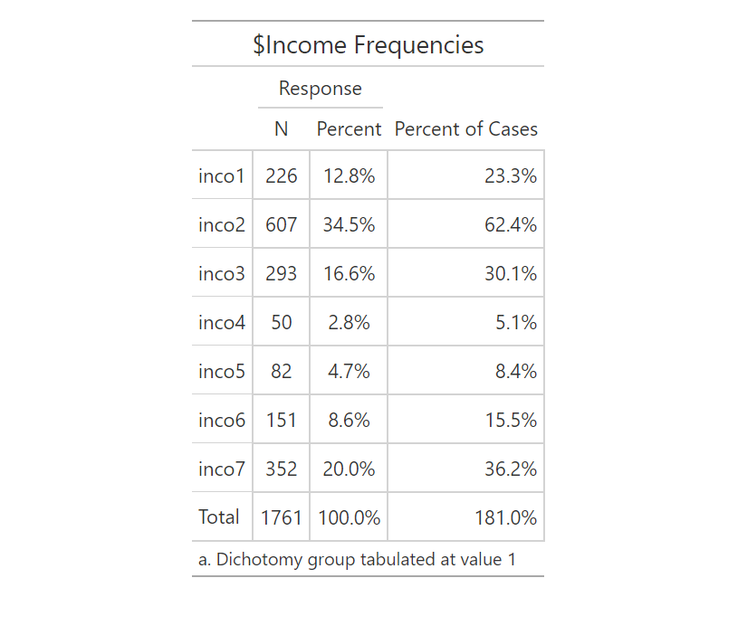

```r
knitr::include_graphics('inco.png')
```

**Load the necessary library needed for Part 2**

```r
library(jsonlite) #for working with json data
library(RSelenium) #for web scraping of dynamic table
library(rvest) #scraping the webpage into tibble or df
library(netstat) #for selenium driver
library(stringr) #string manipulation
```

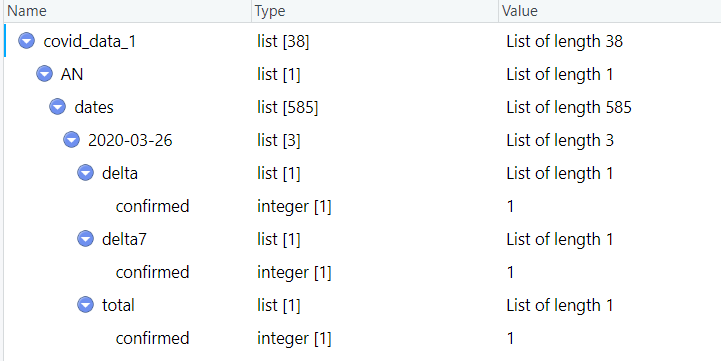

```r
data_1 = 'https://data.covid19india.org/v4/min/timeseries.min.json'
data_2 = 'https://data.covid19india.org/v4/min/data.min.json'
covid_data_1 <- jsonlite::fromJSON(data_1)
covid_data_2 <- jsonlite::fromJSON(data_2)

knitr::include_graphics('cov.png')
```

**Sample of raw json data for first record**

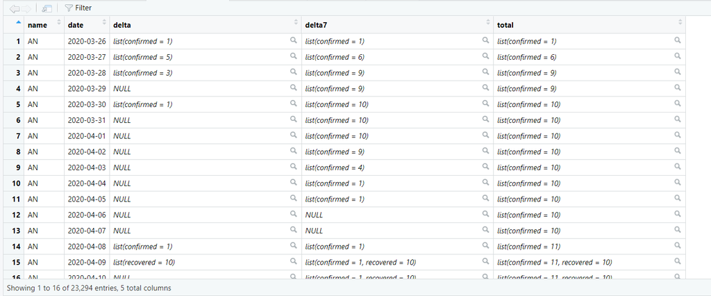

```r
covid_1_parsed <-
  covid_data_1 %>% enframe() %>% unnest_wider(value) %>% unnest_wider(dates) %>%
  pivot_longer(cols = !name,
               names_to = 'date',
               values_to = "value") %>% unnest_wider(value)

knitr::include_graphics("covid.png")
```

**Sample parsed till dates**

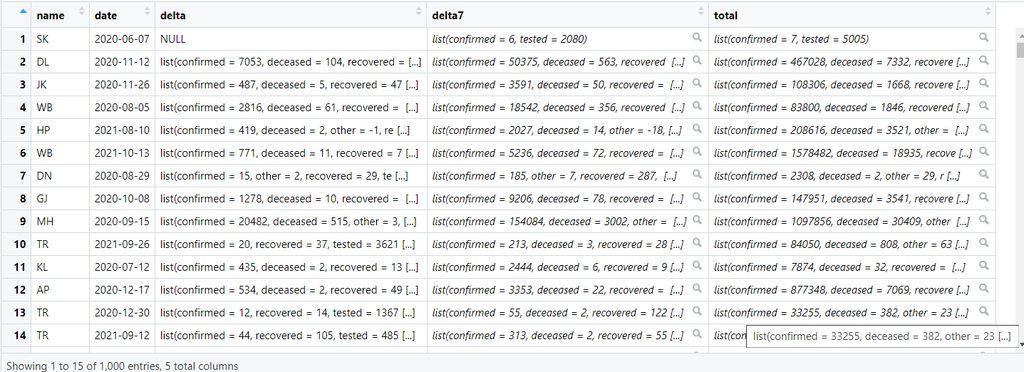

```r
num_rows <- nrow(covid_1_parsed)
selected_rows <- sample(1:num_rows, 1000)
covid_1_parsed_subset <- covid_1_parsed[selected_rows, ]

knitr::include_graphics("covid2.png")
```

```r
covid_1_parsed_subset <- covid_1_parsed_subset %>%
  mutate(across(c(delta, delta7, total), ~ map(., ~ set_names(  as_tibble(.x), paste0(cur_column(), "_", names(.)))))) %>%
  unnest_wider(c(delta, delta7, total))
covid_1_parsed_subset
```

```
## # A tibble: 1,000 × 23
##    name  date       delta_confirmed delta_deceased delta_recovered delta_tested
##    <chr> <chr>                <int>          <int>           <int>        <int>
##  1 UP    2020-08-13            4537             50            4125        88781
##  2 PB    2020-07-28             609             18             688        10896
##  3 CH    2020-05-15              NA             NA               3           81
##  4 ML    2020-03-11              NA             NA              NA           NA
##  5 UT    2020-11-06             473              9             404        11620
##  6 RJ    2020-06-16             235              7             177        13038
##  7 GA    2021-05-23            1621             42            2545         4568
##  8 GA    2020-04-02              NA             NA              NA          220
##  9 HR    2020-04-02               6             NA              NA           NA
## 10 TN    2020-06-24            2865             33            2424        32079
## # ℹ 990 more rows
## # ℹ 17 more variables: delta_other <int>, delta_vaccinated1 <int>,
## #   delta_vaccinated2 <int>, delta7_confirmed <int>, delta7_deceased <int>,
## #   delta7_recovered <int>, delta7_tested <int>, delta7_other <int>,
## #   delta7_vaccinated1 <int>, delta7_vaccinated2 <int>, total_confirmed <int>,
## #   total_deceased <int>, total_recovered <int>, total_tested <int>,
## #   total_other <int>, total_vaccinated1 <int>, total_vaccinated2 <int>
```

```r
# delta parsed
covid_1_parsed_subset[80:150,] %>% select(starts_with('delta'))
```

```
## # A tibble: 71 × 14
##    delta_confirmed delta_deceased delta_recovered delta_tested delta_other
##              <int>          <int>           <int>        <int>       <int>
##  1              70             NA              90        20834          NA
##  2             148              2             111         5977          NA
##  3             336              8             326        15038          NA
##  4              43              1              55         1336           4
##  5             100              1              59         3743          NA
##  6              36             NA              72       157103          NA
##  7              NA             NA              NA           NA          NA
##  8            6190            127            8241        69693           7
##  9            1205             48            5023        75417          NA
## 10              NA             NA              NA           NA          NA
## # ℹ 61 more rows
## # ℹ 9 more variables: delta_vaccinated1 <int>, delta_vaccinated2 <int>,
## #   delta7_confirmed <int>, delta7_deceased <int>, delta7_recovered <int>,
## #   delta7_tested <int>, delta7_other <int>, delta7_vaccinated1 <int>,
## #   delta7_vaccinated2 <int>
```

```r
# delta7 parsed
covid_1_parsed_subset[345:451,] %>% select(starts_with('delta7'))
```

```
## # A tibble: 107 × 7
##    delta7_confirmed delta7_deceased delta7_recovered delta7_tested delta7_other
##               <int>           <int>            <int>         <int>        <int>
##  1             7233              83             6644        112703           NA
##  2                2              NA               NA            NA           NA
##  3              309               4              296         69374           NA
##  4               33              NA               14          3667           NA
##  5             3075             168             5179         22193           NA
##  6            28656              75            26378        341202           NA
##  7            12419             101            10903        195491           NA
##  8              599               3              589        282445           NA
##  9             1563              12             2094         21326           NA
## 10               63              NA               97         10819           NA
## # ℹ 97 more rows
## # ℹ 2 more variables: delta7_vaccinated1 <int>, delta7_vaccinated2 <int>
```

```r
# total parsed
# for delta variants
covid_1_parsed_subset[789:885,] %>% select(starts_with('total'))
```

```
## # A tibble: 97 × 7
##    total_confirmed total_deceased total_recovered total_tested total_other
##              <int>          <int>           <int>        <int>       <int>
##  1          209438           1979          191132      3865194          NA
##  2            3619              7            2074        54660           7
##  3           83475            800           81936      1808372          63
##  4          271114           5235          236651      2924754          NA
##  5         1911231          12919         1865956     22608072          NA
##  6          562072           9975          544705      7497837          NA
##  7            3597             24            1209       137452          NA
##  8             405              4             148        50709          NA
##  9               1             NA              NA           NA          NA
## 10         2506848          33196         2439576     33941304          NA
## # ℹ 87 more rows
## # ℹ 2 more variables: total_vaccinated1 <int>, total_vaccinated2 <int>
```

```r
covid_2_parsed <-
  covid_data_2 %>% enframe() %>% unnest_wider(value) %>%
  unnest_wider(c(delta, delta21_14, delta7, total), names_sep = "_") %>% select(-c(districts, meta))
```

```r
# for delta
covid_2_parsed %>% select(starts_with('delta'))
```

```
## # A tibble: 37 × 15
##    delta_tested delta_vaccinated1 delta_vaccinated2 delta_confirmed
##           <int>             <int>             <int>           <int>
##  1         1376                 3                13              NA
##  2        39848             20497             24137             385
##  3          334                42               195               1
##  4        15060             19124             37463             212
##  5       226443            114694            145827               8
##  6         1403               211              1282               5
##  7        11869             21312             39393              32
##  8        56751             12482             11839              45
##  9           NA                 3                20              NA
## 10         2361              2572             12404              23
## # ℹ 27 more rows
## # ℹ 11 more variables: delta_deceased <int>, delta_recovered <int>,
## #   delta_other <int>, delta21_14_confirmed <int>, delta7_confirmed <int>,
## #   delta7_recovered <int>, delta7_tested <int>, delta7_vaccinated1 <int>,
## #   delta7_vaccinated2 <int>, delta7_deceased <int>, delta7_other <int>
```

```r
# for delta7
covid_2_parsed %>% select(starts_with('delta7'))
```

```
## # A tibble: 37 × 7
##    delta7_confirmed delta7_recovered delta7_tested delta7_vaccinated1
##               <int>            <int>         <int>              <int>
##  1                3                5          8936                884
##  2             2873             3590        254532            1223010
##  3               66               97          4788               3312
##  4             2056             2215        269097             274869
##  5               40               31       1378539            1286708
##  6               28               20         10726               3680
##  7              205              103        147451             379374
##  8              267              239        395086             160323
##  9               NA                2            NA               2802
## 10              222              409         19026               8418
## # ℹ 27 more rows
## # ℹ 3 more variables: delta7_vaccinated2 <int>, delta7_deceased <int>,
## #   delta7_other <int>
```

```r
# for delta21-_14
covid_2_parsed %>% select(starts_with('delta2'))
```

```
## # A tibble: 37 × 1
##    delta21_14_confirmed
##                   <int>
##  1                    9
##  2                 3220
##  3                   87
##  4                 1499
##  5                   30
##  6                   23
##  7                  124
##  8                  195
##  9                    4
## 10                  409
## # ℹ 27 more rows
```

```r
# for total
covid_2_parsed %>% select(starts_with('total'))
```

```
## # A tibble: 37 × 7
##    total_confirmed total_deceased total_recovered total_tested total_vaccinated1
##              <int>          <int>           <int>        <int>             <int>
##  1            7651            129            7518       598033            294001
##  2         2066450          14373         2047722     29518787          32976969
##  3           55155            280           54774      1185436            771875
##  4          610645           5997          600974     24712042          20172463
##  5          726098           9661          716390     50531824          49874828
##  6           65351            820           64495       792851            926035
##  7         1006052          13577          992159     13709510          14851682
##  8         1439870          25091         1414431     29427753          13055636
##  9           10681              4           10644        72410            660753
## 10          178108           3364          174392      1468399           1262568
## # ℹ 27 more rows
## # ℹ 2 more variables: total_vaccinated2 <int>, total_other <int>
```

```r
# merge into single file
merged_df <- merge(covid_1_parsed_subset,
    covid_2_parsed,
    by.x = "name",
    by.y = "name",
    sort = T,
    all = F)

head(merged_df)
```

```
##   name       date delta_confirmed.x delta_deceased.x delta_recovered.x
## 1   AN 2021-10-02                 1               NA                NA
## 2   AN 2020-06-04                NA               NA                NA
## 3   AN 2021-10-28                 1               NA                NA
## 4   AN 2020-11-29                 6               NA                19
## 5   AN 2020-06-17                NA               NA                NA
## 6   AN 2020-04-07                NA               NA                NA
##   delta_tested.x delta_other.x delta_vaccinated1.x delta_vaccinated2.x
## 1           1823            NA                  17                  59
## 2            118            NA                  NA                  NA
## 3           1301            NA                 132                1621
## 4           1581            NA                  NA                  NA
## 5            430            NA                  NA                  NA
## 6             NA            NA                  NA                  NA
##   delta7_confirmed.x delta7_deceased.x delta7_recovered.x delta7_tested.x
```

[output cut: 62 more lines]

#### Webscraping of Dynamic Table AQI Kathmandu

```r
# load the webdriver for firefox
rD <- rsDriver(browser="firefox",verbose = F, port = 14421L)
remDr <- rD[["client"]]
remDr$navigate("https://aqicn.org/forecast/kathmandu/")
aqi_html  <- read_html(remDr$getPageSource() %>% unlist())

# scrape the needed table for data analysis
aqi_html %>% html_element(".forecast-body-table") %>%
  html_nodes("table") %>%
  html_table() ->
  forecast_table
```

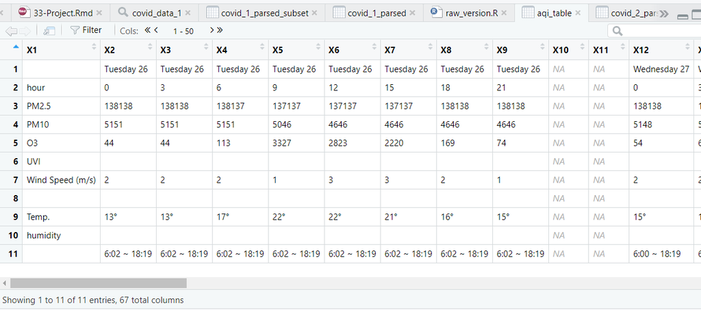

```r
# since forecast consist the list of dataframe
# extracted first value from the list which conists the required dataframe
aqi_table <- forecast_table %>% .[[1]]

knitr::include_graphics('aqi.png')
```

#### **Data Wrangling the forecast Table AQI Kathmandu**

- **Step 1**: Remove null columns that came while parsing  
  `aqi_table %>% select(-c('X10','X11','X20','X21','X30','X31','X40','X41','X50','X51','X60','X61'))`
- **Step 2**: Filter out rows with ‘UVI’ and ‘humidity’ in the ‘X1’ column where entire row is NULL `aqi_table %>% filter(X1 != 'UVI')` and `aqi_table %>% filter(X1 != 'humidity')`
- **Step 3**: Replaced the value in the ‘X1’ column at index 9 with ‘humidity’ `aqi_table %>% mutate(X1 = replace(X1, 9, "humidity"))`
- **Step 4**: Replaced the value in the ‘X1’ column at index 1 with ‘Index’  
  `aqi_table %>% mutate(X1 = replace(X1, 1, "Index"))`
- **Step 5**: Filter out rows with empty values in the ‘X1’ column  
  `aqi_table %>% filter(X1 != '')`
- **Step 6**: Assigned the first row of the data frame as the column headers  
  `headers <- aqi_table[1,]`  
  `colnames(aqi_table) <- headers`
- **Step 7**: Remove the first row of the data frame `aqi_table <- aqi_table[-1,]`
- **Step 8**: Converted the ‘Index’ column to row names `aqi_table %>% column_to_rownames(var = 'Index')`

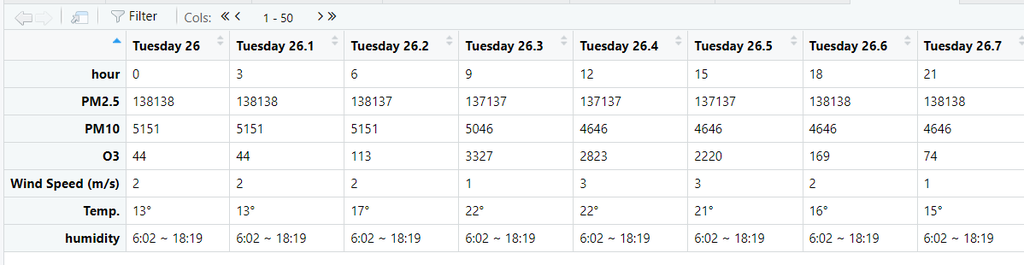

```r
# extract first value from list
aqi_table <- forecast_table %>% .[[1]]

# delete null columns
aqi_table <- aqi_table %>%
  select(-c('X10','X11','X20','X21','X30','X31','X40','X41','X50','X51','X60','X61'))

# remove null row 'UVI'
aqi_table <- aqi_table %>% filter(X1 != 'UVI')

# since value of humidity interchange for now I have removed empty row.
aqi_table <- aqi_table %>% filter(X1 != 'humidity')

# now I have assigned the value at 1st column 9th row as 'humidity'
aqi_table <- aqi_table %>% mutate(X1 = replace(X1, 9, "humidity"))

# now I have assigned the value at 1st column 1st row as 'Index'
aqi_table <- aqi_table %>% mutate(X1 = replace(X1, 1, "Index"))

# finally remove the last empty row
aqi_table <- aqi_table %>% filter(X1 != '')

# setting first row as headers
headers <- aqi_table[1,]
colnames(aqi_table) <- headers

# dropping the first row as header has been set.
aqi_table <- aqi_table[-1,]

# now setting the index or row name as 'Index' column
aqi_table <- aqi_table %>% column_to_rownames(var = 'Index')

knitr::include_graphics('aqi_parse.png')
```

```r
aqi_table[2,] <-
  floor(as.integer(str_extract(as.character(aqi_table[2,]), "\\d+")) / 1000)
aqi_table[3,] <-
  floor(as.integer(str_extract(as.character(aqi_table[3,]), "\\d+")) / 100)

lengths <- as.numeric(nchar(aqi_table[4,]))
aqi_table[4,] <-
  ifelse(lengths == 2, substr(aqi_table[4,], 1, 1),
  ifelse(lengths %in% 3:4, substr(aqi_table[4,], 1, 2), ""))

aqi_table
```

[output not shown]

[output cut: 57 more lines]

```
## hour                        6            9           12           15
## PM2.5                       6            7            8            8
## PM10                       32           42           50           51
## O3
## Wind Speed (m/s)            2            3            6            1
## Temp.                     24°          28°          28°          24°
## humidity         5:55 ~ 18:22 5:55 ~ 18:22 5:55 ~ 18:22 5:55 ~ 18:22
##                      Monday 1
## hour                       18
## PM2.5                       8
## PM10                       51
## O3
## Wind Speed (m/s)            1
## Temp.                     19°
## humidity         5:55 ~ 18:22
```

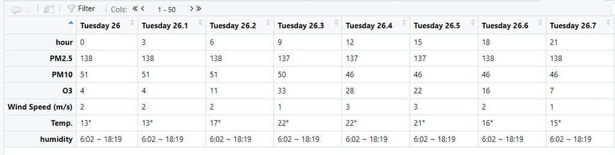

```r
knitr::include_graphics('aqi_final.png')
```

**Final Version of Cleaned AQI Table**

**Load the necessary library needed for Part 3**

```r
library(pdftools) # for working with pdf files
library(tm) # for text mining
```

```r
library(wordcloud) # plotting word cloud
library(Rgraphviz) # plotting network like graph for word association
library(graph) # plotting network like graph for word association
library(ggplot2) # for bargraph
```

**Load the pdf files and convert it to Corpus**

```r
# load the file path in list
files <- list.files(pattern = "pdf$")
```

```r
# load the pdf files into list
pdf_files <- lapply(files, pdf_text)
```

```r
# create a corpus from vector source i.e from list pdf_files
corpus <- Corpus(VectorSource(unlist(pdf_files)))
# copy the loaded corpus
corpus_copy <- corpus
```

```r
# inspect first few texts of corpus
inspect(corpus[1:2])
```

```
## <<SimpleCorpus>>
## Metadata:  corpus specific: 1, document level (indexed): 0
## Content:  documents: 2
##
## [1] See discussions, stats, and author profiles for this publication at: https://www.researchgate.net/publication/260355884\n\n\n\nData Mining in Education\n\nArticle in Wiley Interdisciplinary Reviews: Data Mining and Knowledge Discovery · January 2013\nDOI: 10.1002/widm.1075\n\n\n\n\nCITATIONS …
## [2]  Overview\n\n\n\nData mining in education\nCristobal Romero∗ and Sebastian Ventura\n\n               Applying data mining (DM) in education is an emerging interdisciplinary re-\n              search field also known as educational data mining (EDM). It is concerned with\n              develop…
```

**Text Mining Preprocessing**

- Step 1: Convert all texts to lowercase
- Step 2: Remove punctuation
- Step 3: Remove numbers
- Step 4: Remove stop words or user defined stop words
- Step 5: Stem the corpus
- Step 6: Remove specific words which doesn’t help the corpus
- Step 7: Create Term Document Matrix

```r
# convert the all texts in lower
corpus <- tm_map(corpus, tolower)
inspect(corpus[1:2])
```

```
## <<SimpleCorpus>>
## Metadata:  corpus specific: 1, document level (indexed): 0
## Content:  documents: 2
##
## [1] see discussions, stats, and author profiles for this publication at: https://www.researchgate.net/publication/260355884\n\n\n\ndata mining in education\n\narticle in wiley interdisciplinary reviews: data mining and knowledge discovery · january 2013\ndoi: 10.1002/widm.1075\n\n\n\n\ncitations …
## [2]  overview\n\n\n\ndata mining in education\ncristobal romero∗ and sebastian ventura\n\n               applying data mining (dm) in education is an emerging interdisciplinary re-\n              search field also known as educational data mining (edm). it is concerned with\n              develop…
```

```r
# remove punctuations
corpus <- tm_map(corpus, removePunctuation)
# stem the corpus
corpus <- tm_map(corpus, stemDocument)
remove <- function(x) gsub("values","value",x)
corpus <-  tm_map(corpus, remove)
# create Term Document Matrix with word length 1 or many
tdm <- TermDocumentMatrix(corpus, control = list((wordLenghts=c(1,Inf))))
```

**Best way to create a Term Document Matrix with preprocessing**

```r
remove <- function(x) gsub("values","value",x)
corpus_copy <-  tm_map(corpus_copy, remove)
my_tdm <- TermDocumentMatrix(
  unlist(corpus_copy),
  control =
    list(
      removePunctuation = TRUE,
      stopwords = TRUE,
      tolower = TRUE,
      stemming = FALSE,
      removeNumbers = TRUE,
      bounds = list(global = c(3, Inf)),
      wordLenghts = c(1,Inf),
      removeWords = (c("can","may","used")))
)
```

**Most Frequent Terms**

```r
# finding frequency of words which is at least present 10 times
low_frequent_terms <- findFreqTerms(my_tdm, lowfreq = 10)
head(low_frequent_terms)
```

```
## [1] "article"   "author"    "authors"   "content"   "data"      "discovery"
```

```r
# finding frequency of words which is at max present 10 times
high_frequent_terms <- findFreqTerms(my_tdm, highfreq = 10)
head(high_frequent_terms)
```

```
## [1] "cordoba"           "downloaded"        "interdisciplinary"
## [4] "profile"           "profiles"          "publication"
```

**Associated terms of the most frequent term**

```r
# associated terms for mining with correlation 0.3
findAssocs(my_tdm, "mining", 0.3)
```

```
## $mining
##            data       knowledge       databases       discovery         systems
##            0.55            0.54            0.49            0.45            0.45
##        database           kinds        patterns            user           mined
##            0.44            0.42            0.40            0.39            0.39
##     interactive           users        research        analysis     association
##            0.37            0.37            0.36            0.35            0.34
## interestingness           erent       retrieval           rules      multimedia
##            0.33            0.32            0.31            0.31            0.31
##      challenges      techniques
##            0.30            0.30
```

```r
# associated terms for mining with learning 0.3
findAssocs(my_tdm, "learning", 0.35)
```

```
## $learning
##       machine  intelligence          arti          cial           vol
##          0.74          0.56          0.52          0.50          0.43
##       shavlik        morgan      kaufmann     michalski    statistics
##          0.43          0.42          0.41          0.41          0.40
##        expert      mitchell         ijcai international      learners
##          0.40          0.40          0.39          0.38          0.38
##       quinlan  decisiontree  bibliography     carbonell        kluwer
##          0.38          0.37          0.36          0.36          0.36
##         neter         mateo
##          0.35          0.35
```

```r
# associated terms for mining with data 0.3
findAssocs(my_tdm, "data", 0.4)
```

```
## $data
##      mining    cleaning integration   warehouse  warehouses
##        0.55        0.43        0.42        0.42        0.41
```

**Top 10 words and their respective counts**

```r
# top 10 words and their respective counts

df <-
  my_tdm %>%
  as.matrix() %>%
  rowSums() %>%
  sort(decreasing = TRUE) %>%
  head(10) %>%
  enframe(name = "word", value = "counts")

df
```

```
## # A tibble: 10 × 2
##    word        counts
##    <chr>        <dbl>
##  1 data          8146
##  2 mining        2442
##  3 value         2411
##  4 can           1966
##  5 set           1481
##  6 information   1350
##  7 may           1094
##  8 used           839
##  9 one            820
## 10 variables      780
```

**Bargraph of top 10 words and their respective counts**

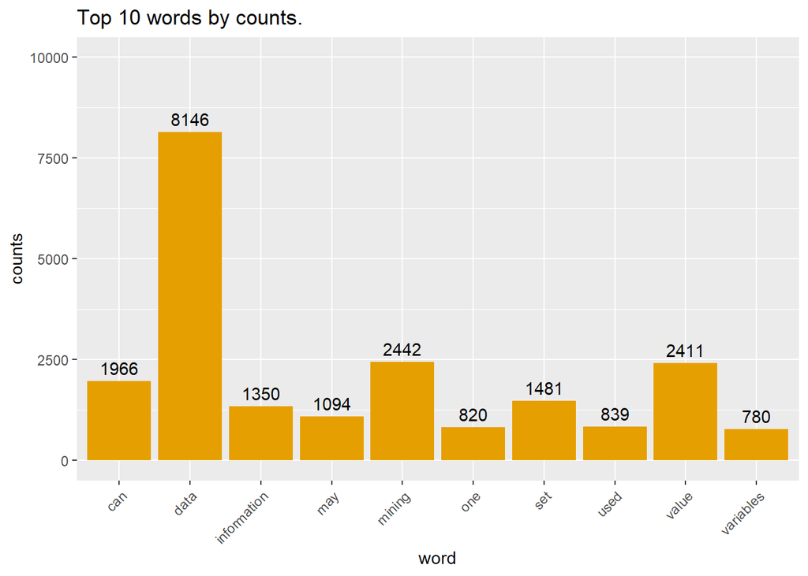

```r
# using ggplot2
bargraph <- ggplot(df, aes(word, counts)) +
  geom_bar(stat = "identity", fill = "#E69F00") +
  theme(axis.text.x = element_text(angle = 45, hjust = 1)) +
  labs(title = "Top 10 words by counts.") +
  geom_text(aes(label = counts), vjust = -0.5) +
  ylim(0, 10000L)

bargraph
```

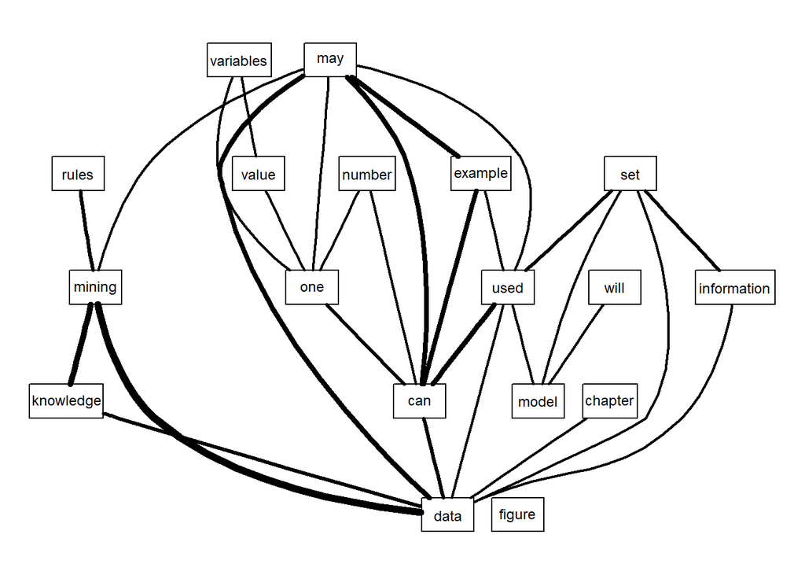

```r
top_650_frequent_tems <- findFreqTerms(my_tdm, lowfreq = 650)
plot(my_tdm, terms = top_650_frequent_tems, corThreshold = 0.2, weighting = T)
```

**Topic Models**

```r
# topic models
library(topicmodels)
set.seed(123)

lda <- LDA(my_tdm, k=4)
```

```r
# terms
head(terms(lda,3))
```

```
##      Topic 1      Topic 2      Topic 3      Topic 4
## [1,] "content872" "content15"  "content173" "content945"
## [2,] "content294" "content947" "content473" "content781"
## [3,] "content390" "content676" "content410" "content686"
```

```r
# topics
head(topics(lda))
```

```
## article  author authors content cordoba    data
##       2       2       2       3       2       2
```